# 1.Prosper Loan Data Exploration

## 1.1 Premilinary Wrangling

##### 1.1.2 What is/are the main feature(s) of interest in your dataset?

I'm most interested in figureing out what features are most common,closely related to one another and that which is best for predicting the borrower's Annual Percentage Rate (APR) anfor the loan

#### 1.1.3 What features in the dataset do you think will help support your investigation into your feature(s) of interest?

I hope to find which categorical variable are most common for in the loan dataset and how closely related some of them are related to one another. I also expect that the total loan amount will have be negatively correlated to the APR of the loan i.e the larger the total loan amount, the lower the APR. I also think that the borrowers stated monthly income, loan term, Prosper rating, employment status will also have effects on the APR.

#### 1.2 Univariate Exploration

##### 1.2a What are the Highest borrowerstate for Prosper Loan users

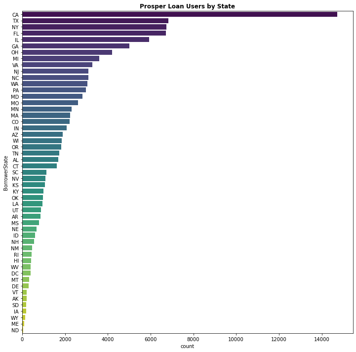

###### 1.3 Question:Whats the Employment status of those that use the ProsperLoan Services

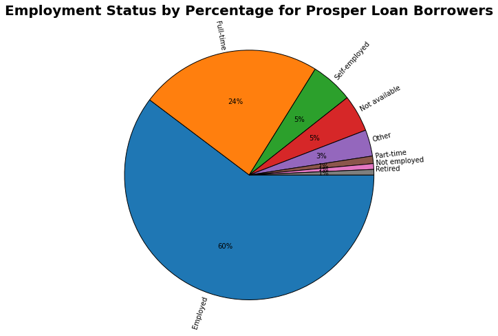

###### Observing the frequency of each employment status of people that make use of the Prosper Loan Services.

From our observation above it goes to show that 60% of prosper loan customers are Employed,24% are employed full-time,5% are self-employed. This goes to show that more than 90% of Prosper Loan customers are those with Employment.

###### Distribution of important numerical columns in the dataset

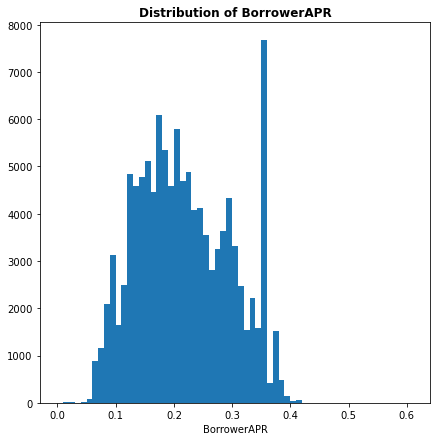

```
['$25,000-49,999',
 '$50,000-74,999',
 '$100,000+',
 '$75,000-99,999',
 'Not displayed',
 '$1-24,999',
 'Not employed',
 '$0']
```

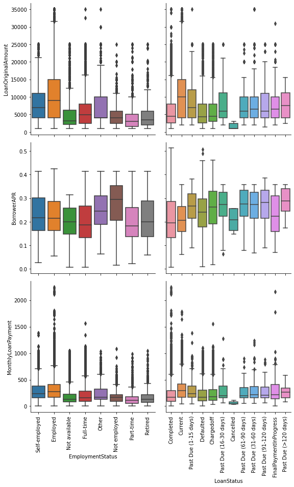

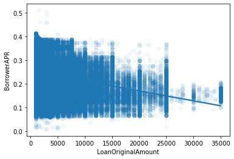

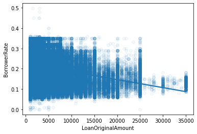

###### The correlation coefficient of borrower APR and loan original amount is -0.32,

the regplot also shows that these two variables are negatively correlated, which agrees with our hypothesis, which means that the more the loan amount, the lower the APR.

###### The Borrower Rate is also negatively Correlated with the LoanOriginal Amount

There is a negative correlation between the LoanOriginalAmount and BorrowerAPR according to the plot above the Borrower APR increases as the LoanOriginalAmount decreases.

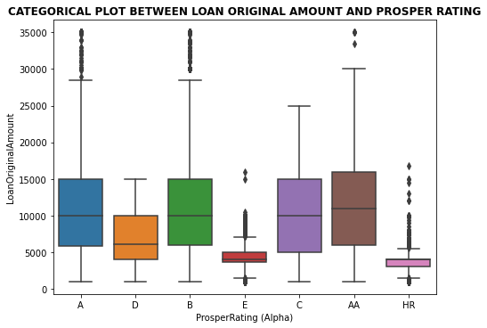

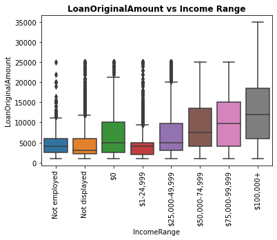

###### In the Bivariate relationship plotted above.

The income range of 1–24,000 has maximum outliers.For income rangeof 50,000 , the loan amount range is also high. However, these ranges do not seem to have any unusual observation/outliers.

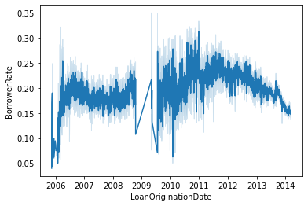